# Lesson_1

Author

Mateusz Rzeszutek

Published

January 2, 2023

## 1 Programowanie

Jest to proces pisania zestawu instrukcji (znanego również kodem), który maszyna może zrozumieć i zmuszania maszyny do ich przestrzegania.

Celem może być rozwiązanie równania matematycznego, zautomatyzowanie nudnego zadania lub stworzenie strony internetowej, oprogramowania, aplikacji mobilnej lub całej gry.

Programowanie komputerowe wymaga umiejętności technicznych i kreatywnego myślenia. Niektórzy nazywają to nauką, inni sztuką.

Aby mieć pełny obraz tego, czym jest programowanie komputerowe, musimy podkreślić dwa punkty w definicji: „zmusić komputery do wykonywania zadań” i „napisać zestaw instrukcji zrozumiałych dla maszyny” . Porozmawiajmy najpierw o instrukcjach.

## 2 Języki programowania

Pomyśl o komputerze jako o swoim **zagranicznym** przyjacielu, który przybył z **przeszłości**. Nie rozumie żadnego języka poza swoim ojczystym. Potrzebuje bardzo prostych i jasnych opisów każdej czynności, które mają zostać wykonane.

Zgodnie z tą logiką nie możesz po prostu powiedzieć swojemu komputerowi, aby „zadzwonił do Dawida z księgowości”. Musisz opisać każde działanie, które obejmuje tą czynność:

1. Odbierz telefon
2. Naciśnij przycisk, aby włączyć ekran
3. Przesuń telefon, aby go odblokować
4. Otwórz Kontakty
5. Wpisz w wyszukiwarce „Steve z księgowości”.
6. Otwórz kontakt Steve’a
7. Naciśnij przycisk połączenia

Komputery nie rozumieją angielskiego ani polskiego, ale rozumieją języki programowania, takie jak C, Python czy Java.

To trochę uproszczenie, ponieważ komputery tak naprawdę ich nie rozumieją — rozumieją tylko **kod maszynowy**. Programiści używają **kompilatorów** do tłumaczenia **kodu źródłowego** na kod maszynowy.

**Czym jest kod maszynowy ?**

Ciąg cyfr binarnych [0,1]

Istnieje ponad tysiąc języków programowania. Stare wciąż ewoluują, a nowe wciąż się pojawiają. Poniżej możesz zobaczyć najpopularniejsze języki programowania w nauce danych.

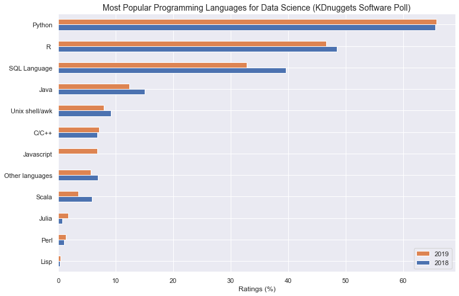

Fig. 1. Top programming languages for data scientists

Każdy język komputerowy ma swoje własne cele i zalety. Niektóre języki lepiej nadają się do określonych aplikacji i zadań. Niektóre języki są trudniejsze, inne mniej. Niektóre są proste i popularne, inne są dopracowane i niszowe. Ważną rzeczą do zapamiętania jest to, że języki programowania mają części, konstrukcje i koncepcje, które są wspólne dla wszystkich z nich. Tak więc nauka innego języka komputerowego będzie równie trudna (lub równie łatwa) jak nauka języka obcego.

Szerszy opis: [KDnuggets](https://www.kdnuggets.com/2019/05/poll-top-data-science-machine-learning-platforms.html)

Ranking języków programowania: [PYPL](https://pypl.github.io/PYPL.html), [TIOBE-index](https://www.tiobe.com/tiobe-index/).

## 3 Jaki język programowania

Wybierając język, powinieneś zadać sobie pytanie, jaki rodzaj pracy chciałbyś wykonywać.

- Chcesz zostać twórcą gier?
- Czy chcesz tworzyć aplikacje na iPhone’a?
- Chcesz robić strony internetowe?
- A może potrzebujesz programowania do automatyzacji pracy z danymi naukowymi i statystycznymi?

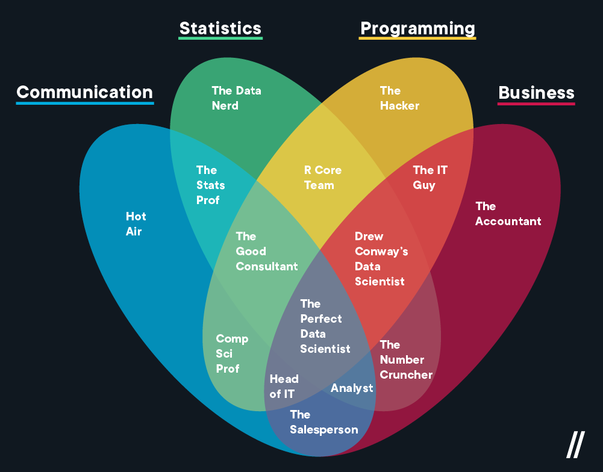

Fig. 2. Data science

**Tip**

Tak naprawdę chodzi o wybór **rodziny języków programowania**.

## 4 Paradygmaty

Różne zadania programistyczne można rozwiązać na różne sposoby: może być konieczne napisanie funkcji lub utworzenie oddzielnej klasy z metodami i tak dalej. Wszystkie takie warianty są łączone w różne podejścia programistyczne, które są również nazywane paradygmatami. Poniżej przeanalizujemy dwa główne paradygmaty: imperatywny i deklaratywny oraz ich rodzaje.

[figure not shown]

Fig. 3 Paradygmaty

**Tip**

Prawie wszystkie współczesne języki są wieloparadygmatowe.

**Important**

Języki programowania niskiego i wysokiego poziomu

Interpretowane i kompilowane języków programowania

## 5 Imperatywny paradygmat

Program rozkazujący jest podobny do poleceń wyrażanych przez tryb rozkazujący w językach naturalnych. Jest to sekwencja instrukcji, które procesor musi wykonać krok po kroku. Głównym celem tego paradygmatu jest sposób osiągnięcia celu. Paradygmat składa się z kilku instrukcji, a po wykonaniu ich wszystkich wynik jest zapisywany.

- zapytaj o nazwę użytkownika
- przeczytaj i zapamiętaj nazwę użytkownika
- wyświetlić wynik

Programowanie imperatywne dzieli się na trzy szerokie kategorie:

- paradygmat programowania **proceduralnego** ,
- programowanie **obiektowe**
- i podejście do **przetwarzania równoległego** .

### 5.1 Paradygmat programowania proceduralnego

Paradygmat programowania proceduralnego opiera się na koncepcji wywołań procedur, w których instrukcje są ustrukturyzowane w procedury zwane również podprogramami lub funkcjami. Są to listy instrukcji, które krok po kroku mówią komputerowi, co ma robić. Innymi słowy, komputer pobiera dane wejściowe i zmienia je sekwencyjnie, pamiętając każdą nową zmianę.

Programowanie proceduralne jest odpowiednie do programowania ogólnego przeznaczenia w celu wykonywania typowych zadań. Może to być więc np. mały problem obliczeniowy. Ponadto kod można ponownie wykorzystać w różnych częściach programu, bez konieczności jego kopiowania.

Algorytm napisany w tym paradygmacie jest bardzo prosty w implementacji, ale jest raczej powolny i nie może rozwiązać złożonego problemu.

Językami programowania, które zaimplementowały paradygmat programowania proceduralnego, są C, Java, C++, ColdFusion i Pascal.

### 5.2 Paradygmat programowania obiektowego

Programowanie zorientowane obiektowo to paradygmat, w którym program jest napisany jako zbiór klas. Każda klasa ma instancje zwane obiektami.

Klasa to ogólny sposób opisywania jednostki, definiujący zwykły stan i zachowanie zależne od tego stanu, a także zwykłe zasady interakcji z tą jednostką. Formalnie klasa jest postrzegana jako zestaw danych, takich jak pola, atrybuty, składowe klasy i funkcje, czyli metody pracy z nimi.

OOP może obsłużyć prawie wszystkie typowe problemy z życia codziennego, w których trzeba modelować typowe obiekty i pracować z nimi.

Języki programowania, które zaimplementowały paradygmat OOP, to Ruby, Java, C++, Python, Simula (pierwszy język OOP), Smalltalk, Visual Basic .NET i Objective-C.

### 5.3 Podejscie do przetwarzania równoległego

Przetwarzanie równoległe pomaga skrócić czas wykonywania instrukcji. Czyni to poprzez udostępnianie lub równoległe wykonywanie instrukcji na wielu procesorach. Znaczenie tego podejścia można streścić w jednym zdaniu: „dziel i zwyciężaj”.

## 6 Paradygmaty deklaratywne

**Programowanie deklaratywne** to paradygmat programowania, w którym ważne jest określenie problemu i oczekiwanego wyniku jego rozwiązania. To znaczy, w przeciwieństwie do imperatywnego paradygmatu, w którym należy odpowiedzieć na pytanie **„jak to zrobić?”** musisz zadać pytania **„Co należy zrobić?”** i **„Jaki będzie wynik pracy?”**.

Zamiast podawać instrukcje krok po kroku, mówisz systemowi, czego potrzebujesz i pozwalasz mu znaleźć rozwiązanie.

[output not shown]

Fig. 4. Znaczenie paradygmatów

Programowanie deklaratywne dzieli się na paradygmaty:

- logiczne,
- funkcjonalne,
- bazodanowe.

**Tip**

Jak tworzyć diagramy: [quarto-diagrams](https://quarto.org/docs/authoring/diagrams.html), [mermaid](https://mermaid.js.org/).

### 6.1 Paradygmat programowania w logice

*Programowanie logiczne* to paradygmat programowania, który w dużej mierze opiera się na logice formalnej. Każdy program napisany w języku programowania logicznego jest zbiorem zdań w logicznej formie, które wyrażają fakty i reguły dotyczące określonego obszaru problemowego.

Tak więc podstawowe instrukcje programowania logicznego są następujące:

- **Fakty** to fundamentalne twierdzenia dotyczące domeny problemowej, takie jak „Sokrates jest człowiekiem”.
- **Reguły** są wnioskami na temat faktów w domenie („Wszyscy ludzie są śmiertelni”).
- **Zapytania** to pytania dotyczące tej domeny („Czy Sokrates jest śmiertelny?”)

Ogólnie rzecz biorąc, zadaniem tutaj jest znalezienie odpowiedzi na zapytanie w oparciu o fakty i reguły.

Główne rodziny języków programowania logicznego obejmują Prolog, programowanie zestawu odpowiedzi (ASP) i Datalog.

### 6.2 Paradygmat programowania funkcyjnego

Programowanie funkcyjne to paradygmat programowania, w którym proces obliczeniowy jest interpretowany jako obliczanie wartości funkcji. Funkcja w tym przypadku jest podobna do funkcji matematycznej. To znaczy funkcja, w której wejściem jest tablica, która nie jest zmieniana, a wyjściem jest nowa tablica z nowymi danymi. To sprawia, że funkcja matematyczna różni się od funkcji w programowaniu proceduralnym, gdzie funkcja jest sekwencją działań zmieniających oryginalne dane.

Oto prosty przykład: możesz mieć funkcję, która pobiera listę liczb jako dane wejściowe i zwraca nową listę z kwadratami tych liczb. Nie zmienia to oryginalnej listy numerów.

Języki programowania, które zaimplementowały paradygmat programowania funkcyjnego, to JavaScript, Haskell, Scala, Erlang, Lisp, ML, Clojure, OCaml i F#.

### 6.3 Paradygmat programowania baz danych

Ta metodologia programowania opiera się na pracy z danymi. Dane są przechowywane w bazie danych i zapytania są kierowane do tej bazy danych w specjalnym języku, na przykład SQL. Za pomocą tych języków można uzyskać dostęp do danych w celu filtrowania, przekształcania, obliczania statystyk i tak dalej. Instrukcje programu są definiowane przez dane, a nie zakodowane na stałe serie kroków.

Program bazy danych jest sercem systemu informacji biznesowej, umożliwiając tworzenie plików, wprowadzanie danych, aktualizowanie, wysyłanie zapytań i funkcje raportowania.

### 6.4 Podsumowanie parydygmatów

- Różne podejścia do tworzenia programów nazywane są paradygmatami.
- Istnieją dwa główne paradygmaty programowania: imperatywny i deklaratywny.
- Imperatywny paradygmat koncentruje się na osiągnięciu wyniku za pomocą instrukcji krok po kroku, które sekwencyjnie zmieniają dane.
- Paradygmat imperatywny obejmuje paradygmat programowania proceduralnego, programowanie obiektowe i podejście do przetwarzania równoległego.
- Paradygmat deklaratywny koncentruje się na zadaniu i stara się uzyskać oczekiwany rezultat.
- Paradygmat deklaratywny obejmuje paradygmaty logiczne, funkcjonalne i bazy danych.